# Class Questionnaire: Data Cleaning

STAT 230

Feb 2, 2017

## Data Cleaning

Data cleaning is a critical first step in most data analysis. We will spend some time cleaning up the rest of this raw dataset. Let’s start by loading in the raw data again.

```r
x <- read.csv("stat_230_survey_raw.csv",
              as.is = TRUE)
str(x)
```

```
## 'data.frame':    93 obs. of  24 variables:
##  $ Pcredit        : num  0.8 1 1 0.5 1 1 1 0.8 0.75 1 ...
##  $ UorG           : chr  "Graduate student" "Graduate student" "Undergraduate student" "Undergraduate student" ...
##  $ Year           : chr  "1 = freshman or first year grad" "2 = sophomore or 2nd year grad" "4 = senior or 4th year grad" "4 = senior or 4th year grad" ...
##  $ Major          : chr  "Physical sciences, engineering, or math" "Life sciences" "Social sciences" "Life sciences" ...
##  $ Gender         : chr  "Female" "Male" "Male" "Male" ...
##  $ Height         : chr  "62" "69" "75" "69" ...
##  $ Weight         : num  130 240 170 203 130 ...
##  $ Handedness     : chr  "Right handed" "Right handed" "Right handed" "Right handed" ...
##  $ Politics       : chr  "Somewhat liberal" "Moderate" "Somewhat conservative" "Somewhat liberal" ...
##  $ Political_Party: chr  "Democratic" "Other party" "Republican" "Democratic" ...
##  $ SAT_CR         : chr  "700" "740" "800" "800" ...
##  $ SAT_M          : chr  "800" "680" "780" "800" ...
##  $ SAT_W          : chr  "750" "700" "800" "790" ...
##  $ High.school.GPA: num  4 3.62 4.4 4 3.9 4 4.25 NA 3.95 4 ...
##  $ College.GPA    : num  3.8 3.7 3.95 3.92 3.9 NA 3.9 NA 3.86 3.88 ...
##  $ Television     : chr  "0" "45" "5" "38.6" ...
##  $ Web            : num  120 30 90 360 100 120 90 NA 30 60 ...
##  $ Exercise       : num  10 10 20 40 30 0 30 NA 60 30 ...
##  $ Academics      : int  240 240 240 45 360 0 120 NA 480 360 ...
##  $ Attendance     : num  0.9 0.97 1 0.95 1 0.9 1 NA 0.95 0.75 ...
##  $ Computer       : chr  "Windows" "Mac" "Mac" "Windows" ...
##  $ Pulse          : int  68 87 NA NA NA 60 72 NA 54 72 ...
##  $ Haircut        : chr  "30" "15" "20" "35" ...
##  $ TimeMachine    : chr  "30 AD" "1988" "1980" "" ...
```

We will now iterate over each of the variables in turn to check for any issues that need fixing.

```r
summary(x$Pcredit)
```

```
##    Min. 1st Qu.  Median    Mean 3rd Qu.    Max.    NA's
##  0.1000  0.8000  1.0000  0.8873  1.0000  1.0000       1
```

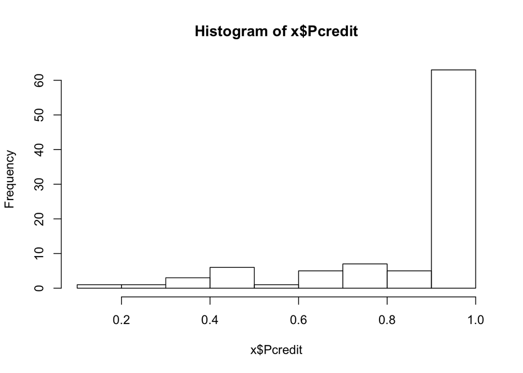

```r
hist(x$Pcredit)
```

```r
table(x$UorG)
```

```
##
##                            Graduate student               Neither
##                     1                    22                     1
## Undergraduate student
##                    69
```

There’s a missing value here… see the 1 lingering on the left? In fact, let’s take a peek at this individual.

```r
x[x$UorG == "",]
```

```
##    Pcredit UorG Year Major Gender Height Weight Handedness Politics
## 76       1                                   NA
##    Political_Party SAT_CR SAT_M SAT_W High.school.GPA College.GPA
## 76                                                 NA          NA
##    Television Web Exercise Academics Attendance Computer Pulse Haircut
## 76             NA       NA        NA         NA             NA
##    TimeMachine
## 76
```

It appears that this person only answered the first question before submitting. How do we want to handle this row? Suppose we decide we simply don’t trust the data (not even the 1 for `Pcredit`). Then, we might decide to take this row out entirely.

```r
x <- x[x$UorG != "",]
```

**A suggestion from last class…**

Can we just replace all blanks with NA simultaneously?

```r
x[x==""] <- NA
```

```r
table(x$UorG)
```

```
##
##      Graduate student               Neither Undergraduate student
##                    22                     1                    69
```

We can still abbreviate the labels:

```r
x$UorG[x$UorG == "Graduate student"] <- "Grad"
x$UorG[x$UorG == "Undergraduate student"] <- "Undergrad"
table(x$UorG)
```

```
##
##      Grad   Neither Undergrad
##        22         1        69
```

Let’s take a look at ‘Year’:

```r
table(x$Year)
```

```
##
## 1 = freshman or first year grad  2 = sophomore or 2nd year grad
##                              24                              31
##     3 = junior or 3rd year grad     4 = senior or 4th year grad
##                              16                              16
##                 Beyond 4th year
##                               3
```

```r
x$Year[x$Year == "1 = freshman or first year grad"] <- "1"
unique(x$Year)
```

```
## [1] "1"                              "2 = sophomore or 2nd year grad"
## [3] "4 = senior or 4th year grad"    "3 = junior or 3rd year grad"
## [5] NA                               "Beyond 4th year"
```

To save ourselves some typing:

```r
x$Year[grep("2 =", x$Year)] <- "2"
x$Year[grep("3 =", x$Year)] <- "3"
x$Year[grep("4 =", x$Year)] <- "4"
x$Year[grep("Beyond", x$Year)] <- "4+"
unique(x$Year)
```

```
## [1] "1"  "2"  "4"  "3"  NA   "4+"
```

```r
table(x$Year)
```

```
##
##  1  2  3  4 4+
## 24 31 16 16  3
```

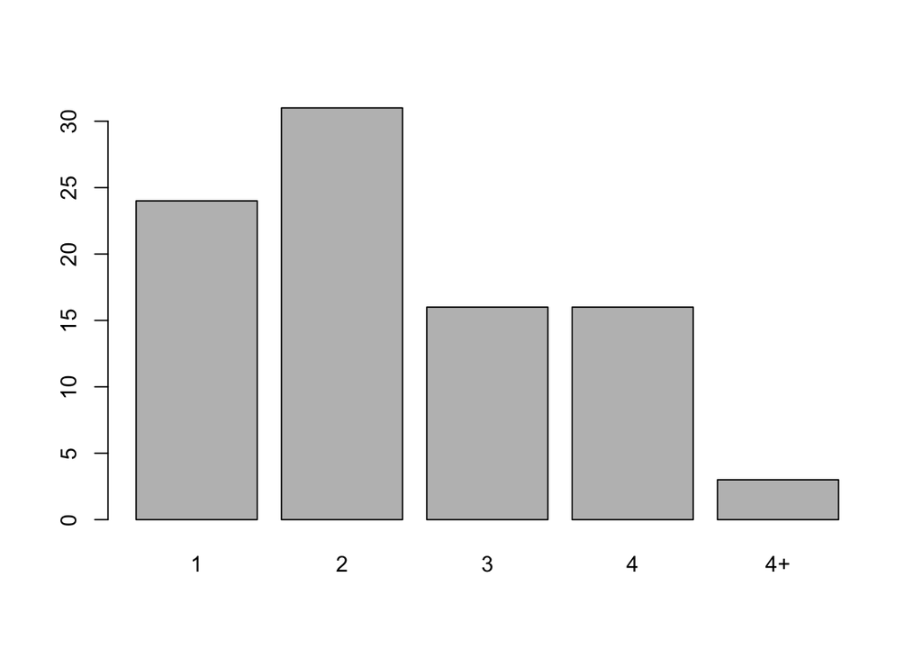

```r
barplot(table(x$Year))
```

```r
class(x$Year)
```

```
## [1] "character"
```

Height

```r
x$Height
```

```
##  [1] "62"     "69"     "75"     "69"     "64"     "62"     "65"
##  [8] NA       "69"     "6' 1\"" "66"     "75"     "61.5"   "71"
## [15] "68"     "72"     "69"     "74"     "67"     "56"     "66"
## [22] "71"     "73"     "67"     "61.5"   "65"     "65"     "67"
## [29] "68"     "6'3\""  "64"     "69.75"  "61"     "74"     "69.5"
## [36] "63"     NA       "66.9"   "61"     "67"     "61"     "6"
## [43] "67"     "67.5"   "162"    "72"     "67"     "5.25"   "66"
## [50] "63"     "71"     "67"     "57"     NA       "68"     "68"
## [57] "73"     "72"     "65"     "67"     "67"     "72"     "5:03"
## [64] "67"     "78"     "4' 2\"" "65"     "66"     "68.25"  "70"
## [71] "5"      "62"     "68"     NA       "68"     "64"     "67"
## [78] "64"     "66"     "68"     "66"     "64.2"   "69"     "69"
## [85] "76"     "74"     "67"     "68"     "70"     "68"     "75"
## [92] "73"
```

```r
# input: 'z' a vector that is supposedly numeric but has nonnumeric values
# output: a vector of indices corresponding to those nonnumeric values
findNonNumbers <- function(z) {
  return(which(is.na(as.numeric(z))))
}

temp <- findNonNumbers(x$Height)
temp
```

```
## [1]  8 10 30 37 54 63 66 74
```

```r
x$Height[temp[1]] # nothing to do, started as an NA
```

```
## [1] NA
```

```r
x$Height[temp[2]] <- 6*12+1
x$Height[temp[2]]
```

```
## [1] "73"
```

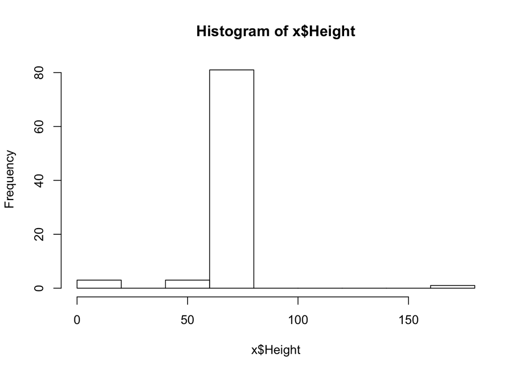

```r
x$Height[temp[3]] <- 6*12+3
x$Height[temp[6]] <- 5*12+3
x$Height[temp[7]] <- 4*12+2
x$Height <- as.numeric(x$Height)
hist(x$Height)
```

Who are the outliers?

```r
x[which(x$Height > 100),]
```

```
##    Pcredit UorG Year      Major Gender Height Weight   Handedness Politics
## 45     0.5 Grad   4+ Humanities Female    162     50 Right handed Moderate
##               Political_Party SAT_CR SAT_M SAT_W High.school.GPA
## 45 Not interested in politics   <NA>  <NA>  <NA>              NA
##    College.GPA Television Web Exercise Academics Attendance Computer Pulse
## 45         3.8          2  10      0.5         5          1      Mac   100
##    Haircut TimeMachine
## 45      30        2008
```

```r
x$Weight[which(x$Height > 100)] <- 110.23
x$Height[which(x$Height > 100)] <- 162/2.54

x[which(x$Height < 30),]
```

```
##    Pcredit    UorG Year                                   Major Gender
## 42       1 Neither <NA>                         Other or unsure   Male
## 48       1    Grad    1 Physical sciences, engineering, or math Female
## 71       1    Grad    1 Physical sciences, engineering, or math Female
##    Height Weight   Handedness              Politics
## 42   6.00    200 Right handed Somewhat conservative
## 48   5.25    110 Right handed              Moderate
## 71   5.00    120 Right handed Somewhat conservative
##               Political_Party SAT_CR SAT_M SAT_W High.school.GPA
## 42                 Republican   <NA>  <NA>  <NA>              NA
## 48 Not interested in politics   <NA>  <NA>  <NA>              NA
## 71                 Republican    770   770   770               4
##    College.GPA Television Web Exercise Academics Attendance Computer Pulse
## 42          NA          0 120      120       360       0.90      Mac    72
## 48        3.58          0 240       30       240       0.90      Mac    75
## 71        3.78         30 120       30        NA       0.97      Mac    NA
##    Haircut         TimeMachine
## 42      50                   0
## 48      15 back to 4 years old
## 71      60                2011
```

```r
# if we believe these are all in units of feet, we can fix them together
x$Height[which(x$Height < 30)]
```

```
## [1] 6.00 5.25 5.00
```

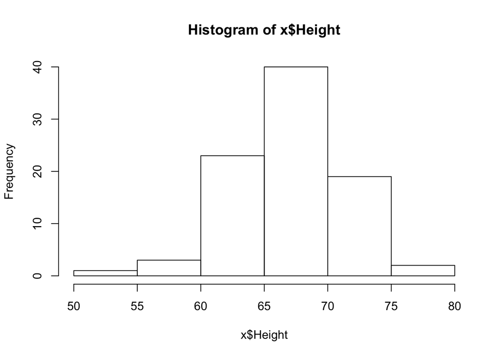

```r
x$Height[which(x$Height < 30)] <- x$Height[which(x$Height < 30)]*12
hist(x$Height)
```

SAT scores:

```r
x$SAT_CR[findNonNumbers(x$SAT_CR)]
```

```
##  [1] NA    NA    NA    NA    NA    NA    NA    NA    NA    NA    "n/a"
## [12] NA    NA    NA    NA    NA    NA    NA    NA    NA    NA    NA
```

```r
x$SAT_M[findNonNumbers(x$SAT_M)]
```

```
##  [1] NA    NA    NA    NA    NA    NA    NA    NA    NA    NA    "n/a"
## [12] NA    NA    NA    NA    NA    NA    NA    NA    NA    NA
```

```r
x$SAT_W[findNonNumbers(x$SAT_W)]
```

```
##  [1] NA    NA    NA    NA    NA    NA    NA    NA    NA    NA    NA
## [12] "n/a" NA    NA    NA    NA    NA    NA    NA    NA    NA    NA
```

```r
x[x == "n/a"] <- NA
x$SAT_CR <- as.numeric(x$SAT_CR)
x$SAT_M <- as.numeric(x$SAT_M)
x$SAT_W <- as.numeric(x$SAT_W)
```

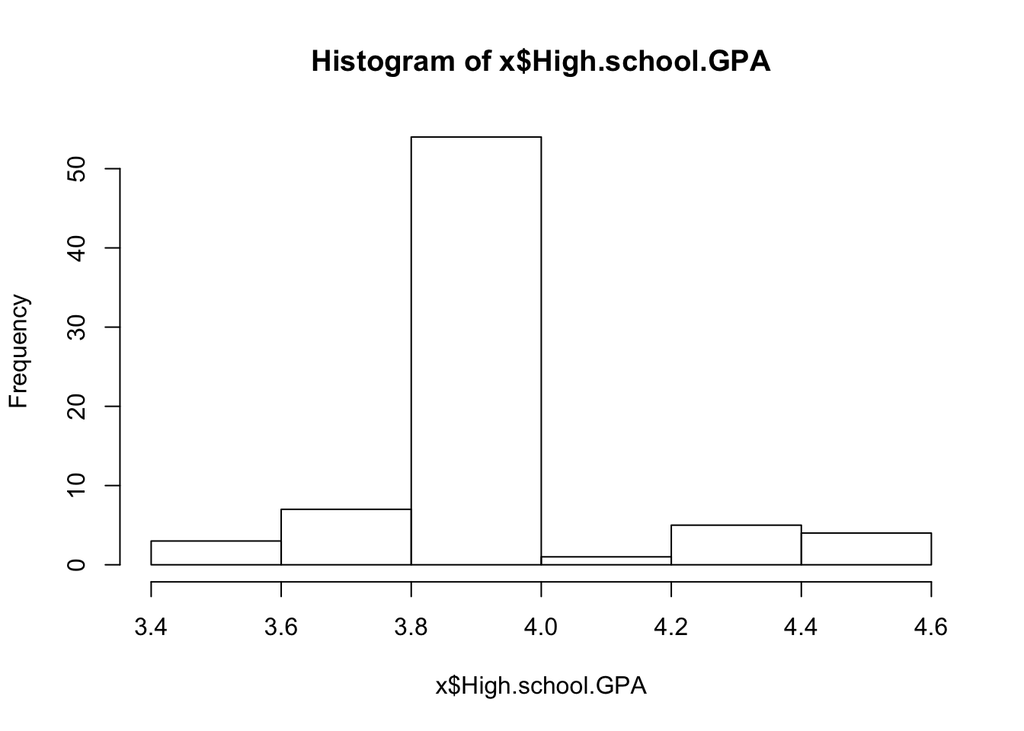

```r
hist(x$High.school.GPA)
```

Television:

```r
x$Television[findNonNumbers(x$Television)]
```

```
## [1] NA   NA   "f0" NA   NA   NA   NA
```

```r
x$Television <- as.numeric(x$Television)
```

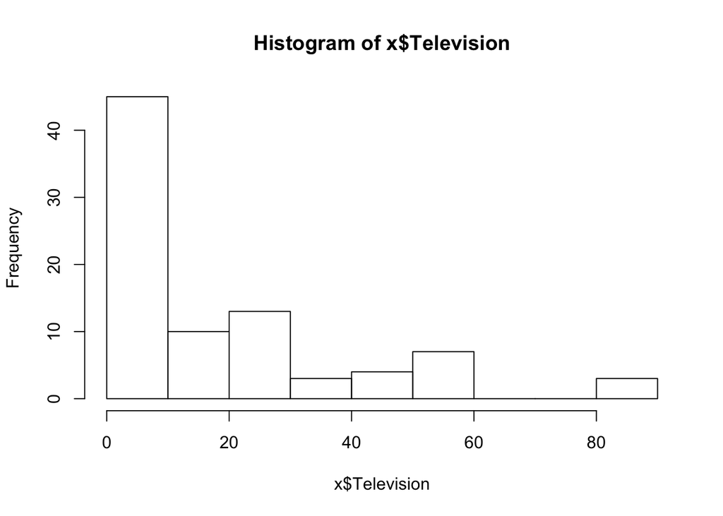

```r
hist(x$Television)
```

```r
sort(x$Television)
```

```
##  [1]  0.00  0.00  0.00  0.00  0.00  0.00  0.00  0.00  0.00  0.00  0.00
## [12]  0.00  0.00  0.00  0.00  0.00  0.00  0.00  0.00  0.00  0.00  0.00
## [23]  0.00  0.00  0.00  0.00  0.00  0.01  0.25  0.33  0.50  1.00  2.00
## [34]  4.00  5.00  5.00  5.00  5.00  8.00 10.00 10.00 10.00 10.00 10.00
## [45] 10.00 15.00 15.00 15.00 15.00 15.00 15.00 15.00 20.00 20.00 20.00
## [56] 22.00 25.00 25.00 30.00 30.00 30.00 30.00 30.00 30.00 30.00 30.00
## [67] 30.00 30.00 38.60 40.00 40.00 45.00 45.00 45.00 50.00 60.00 60.00
## [78] 60.00 60.00 60.00 60.00 60.00 90.00 90.00 90.00
```

```r
x[which(x$Television > 0 & x$Television < 5),
  c("Television", "Web", "Exercise",
                                         "Academics")]
```

```
##    Television  Web Exercise Academics
## 18       0.33  5.0     60.0       120
## 24       0.25  1.0      0.0       180
## 30       4.00 80.0     60.0       200
## 32       0.50  1.5     30.0       180
## 38       0.01  0.5     30.0       120
## 45       2.00 10.0      0.5         5
## 85       1.00  1.0     30.0         3
```

```r
temp <- findNonNumbers(x$Haircut)
```

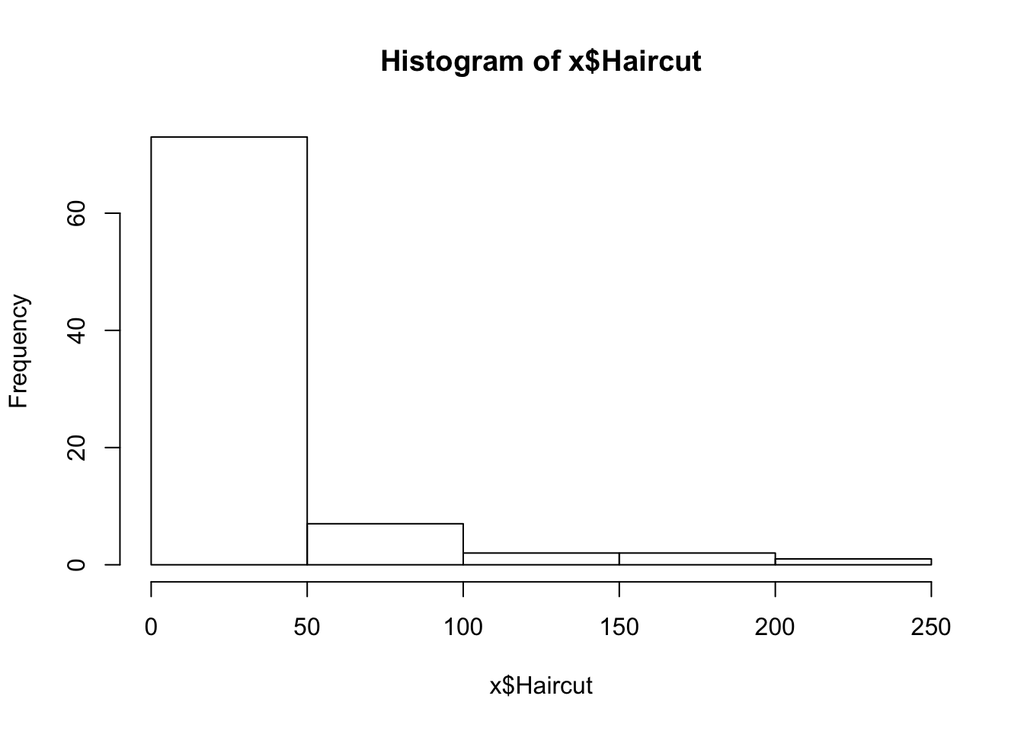

```r
x$Haircut[temp[2]] <- 10
x$Haircut[temp[5]] <- 45
x$Haircut[temp[6]] <- 0
x$Haircut <- as.numeric(x$Haircut)
hist(x$Haircut)
```